# Financial Forecasting in R

Time-Series Prediction with the forecast Package

# 1. Forecast: Time-Series Prediction

### What is Forecasting?

Forecasting uses historical data to predict future values.

In Finance, forecasting is used for: - Stock Prices - Interest Rates - Exchange Rates - Sales Revenue - Economic Indicators

Popular Forecasting Models: - ARIMA - ETS (Exponential Smoothing) - Moving Average

### Install Required Package (Once)

```r
install.packages("forecast")
```

### Load Required Package

```r
library(forecast)
```

### Create Sample Financial Data

Suppose this represents a stock’s monthly closing price.

```r
stock_prices <- c(
  100,102,105,107,110,112,
  115,117,120,123,125,128
)

stock_prices
```

```
 [1] 100 102 105 107 110 112 115 117 120 123 125 128
```

### Convert to Time Series

```r
stock_ts <- ts(stock_prices,
               start = c(2025,1),
               frequency = 12)

stock_ts
```

```
     Jan Feb Mar Apr May Jun Jul Aug Sep Oct Nov Dec
2025 100 102 105 107 110 112 115 117 120 123 125 128
```

### Visualize the Trend

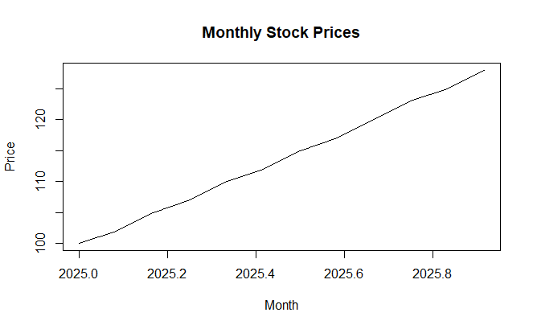

```r
plot(stock_ts,
     main="Monthly Stock Prices",
     ylab="Price",
     xlab="Month")
```

**Discussion Point for Students:** > *Question:* Is the stock moving upward or downward? > *Answer:* Upward trend.

# 2. ARIMA Forecasting

### What is ARIMA?

ARIMA learns patterns from historical data and predicts future values. It is widely used in stock analysis, interest rate forecasting, and economic modeling.

### Build ARIMA Model

R automatically selects the best ARIMA parameters when using `auto.arima()`.

```r
arima_model <- auto.arima(stock_ts)

arima_model
```

```
Series: stock_ts
ARIMA(1,1,0) with drift

Coefficients:
          ar1   drift
      -0.8193  2.5495
s.e.   0.1554  0.0495

sigma^2 = 0.1012:  log likelihood = -2.4
AIC=10.81   AICc=14.24   BIC=12
```

### Predict Next 6 Months

```r
arima_forecast <- forecast(arima_model, h = 6)

arima_forecast
```

|  | Point Forecast | Lo 80 | Hi 80 | Lo 95 | Hi 95 |
| --- | --- | --- | --- | --- | --- |
| Jan 2026 | 130.1804 | 129.7728 | 130.5881 | 129.5570 | 130.8039 |
| Feb 2026 | 133.0323 | 132.6181 | 133.4466 | 132.3988 | 133.6659 |
| Mar 2026 | 135.3341 | 134.7935 | 135.8747 | 134.5074 | 136.1608 |
| Apr 2026 | 138.0866 | 137.5322 | 138.6410 | 137.2387 | 138.9345 |
| May 2026 | 140.4698 | 139.8362 | 141.1034 | 139.5008 | 141.4388 |
| Jun 2026 | 143.1555 | 142.5029 | 143.8082 | 142.1575 | 144.1536 |

### Plot Forecast

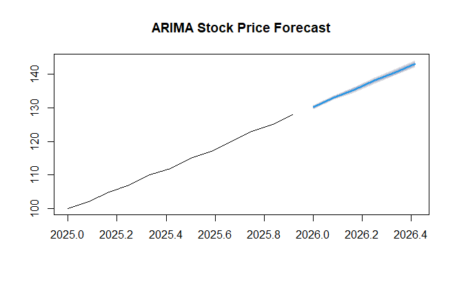

```r
plot(arima_forecast, main="ARIMA Stock Price Forecast")
```

**Interpretation Key:**

- **Black Line:** Historical prices

- **Blue Line Extension:** Predicted future stock prices

- **Shaded Region:** Uncertainty/confidence interval

# 3. ETS Forecasting

### What is ETS?

ETS stands for **Error, Trend, and Seasonality**. It is another popular exponential smoothing framework for forecasting.

### Build ETS Model

```r
ets_model <- ets(stock_ts)

ets_model
```

```
ETS(A,A,N)

Call:
ets(y = stock_ts)

  Smoothing parameters:
    alpha = 1e-04
    beta  = 1e-04

  Initial states:
    l = 97.0585
    b = 2.5538

  sigma:  0.3579

     AIC     AICc      BIC
10.29297 20.29297 12.71750
```

### Forecast Next 6 Months

```r
ets_forecast <- forecast(ets_model, h = 6)

ets_forecast
```

|  | Point Forecast | Lo 80 | Hi 80 | Lo 95 | Hi 95 |
| --- | --- | --- | --- | --- | --- |
| Jan 2026 | 130.2583 | 129.7996 | 130.7170 | 129.5568 | 130.9598 |
| Feb 2026 | 132.8121 | 132.3535 | 133.2708 | 132.1107 | 133.5136 |
| Mar 2026 | 135.3660 | 134.9073 | 135.8246 | 134.6645 | 136.0674 |
| Apr 2026 | 137.9198 | 137.4612 | 138.3785 | 137.2184 | 138.6213 |
| May 2026 | 140.4737 | 140.0150 | 140.9323 | 139.7722 | 141.1751 |
| Jun 2026 | 143.0275 | 142.5688 | 143.4862 | 142.3260 | 143.7290 |

### Plot ETS Forecast

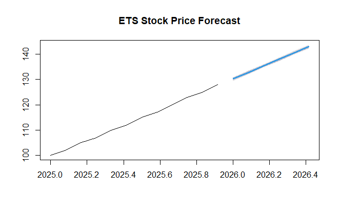

```r
plot(ets_forecast, main="ETS Stock Price Forecast")
```

# 4. Compare ARIMA and ETS

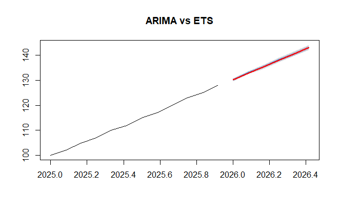

```r
plot(arima_forecast, main="ARIMA vs ETS")
lines(ets_forecast$mean, col="red", lwd=2)
```

**Interpretation Key:**

- **Blue Line:** ARIMA prediction

- **Red Line:** ETS prediction

- *Note:* Different models can produce slightly different mathematical trajectories based on how they weight historical data.

# 5. Real Financial Example: Interest Rates

### Create Interest Rate Dataset

```r
interest_rates <- c(
  5.0,5.1,5.2,5.3,5.4,5.5,
  5.6,5.7,5.8,5.9,6.0,6.1
)

rate_ts <- ts(interest_rates, frequency = 12)
```

### Forecast Future Interest Rates

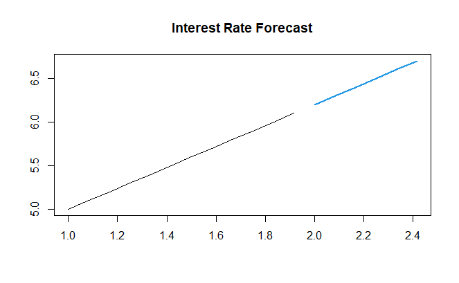

```r
rate_model <- auto.arima(rate_ts)
rate_forecast <- forecast(rate_model, h = 6)

plot(rate_forecast, main="Interest Rate Forecast")
```

# 6. Forecast Accuracy

How well does the model fit past data? We use evaluation metrics to check performance.

```r
accuracy(arima_forecast)
```

```
                       ME      RMSE       MAE         MPE      MAPE MASE       ACF1
Training set -0.009852172 0.2754691 0.1629236 -0.01433756 0.1418361  NaN -0.1990286
```

**Common Metrics:** - **MAE:** Mean Absolute Error - **RMSE:** Root Mean Square Error - *Rule:* Smaller error values indicate better, tighter mathematical predictions.

**Quick Business Interpretation:** If your forecast output shows: - Month 13: 130 - Month 14: 132 - Month 15: 134

> *Takeaway:* Based purely on historical trends, the asset value is structurally expected to continue its upward expansion over the next quarter.

# Final Lesson Summary

### ARIMA

✔ Learns patterns from historical data (`auto.arima()`, `forecast()`)

- Used for volatile market assets, stock prices, and economic indicators.

### ETS

✔ Models error, trend, and seasonality directly (`ets()`, `forecast()`)

- Excellent for smooth, seasonal business trends and revenue forecasting.

### Visualizing Forecasts

✔ `plot(forecast_object)` plots history, predictions, and confidence risk blocks instantly.